# Final Project: R Reference

Timothy Nsubuga

12/2/2021

# R Reference Guide

## Loading Data and Packages

### libary()

**The function library() loads an R package (code, documentation, data).**

Here is an example using the built in Palmer Penguins package.

```r
library(palmerpenguins)
```

### require()

**The require function also loads and R package (necessary when working in an R markdown in which a new R session is created every time the document is run).**

Here is an example using the Here package.

```r
require(here)
```

### here()

**The here function returns any subdirectory’s file within an r project regardless of what the working directory is.**

### read.csv()

**The read.csv function converts a .csv file into tabulated data, converting it into a data frame.**

Here is an example using both here() and read.csv() functions on 2021 ginkgo data.

```r
ginkgo = read.csv(here("data","ginkgo_data_2021.csv"))
```

## Data Strucutures

### c()

**The function c() combines or concatenates its arguments into a vector (a 1-dimensional data structure consisting of 1 or more elements).**

- All of the elements must be of the same type.
- I can’t combine character and numeric types in the same call to c()

Here’s two examples using numeric and character data types:

```r
## Create a vector of numbers:
num_vec  = c(1, 4, 8, 9, 13)

## Create a vector of characters:
char_vec = c("a", "fish", "data is cool")
```

I can show the contents of a vector by typing the name of the vector, or using the print() function.

Typing the name of the vector into the console prints the contents

```r
## Typing the name of the vector into the console prints the contents
num_vec
```

```
## [1]  1  4  8  9 13
```

```r
## The print() function accomplishes the same task:
print(char_vec)
```

```
## [1] "a"            "fish"         "data is cool"
```

### length()

**The function length() returns the number of elements contained in a vector.**

Here’s two examples using numeric and character data types:

```r
## Create a vector of numbers:
num_vec2  = c(5, 10, 36, 37, 45)

## Create a vector of characters:
char_vec2 = c("T", "ginkgo", "data is pretty cool")

## Get length of num_vec2 and char_vec2

length(num_vec2)
```

```
## [1] 5
```

```r
length(char_vec2)
```

```
## [1] 3
```

### matrix()

**The function matrix() creates a 2-dimensional array(default: by column) of 1 data type from a given vector, designated number of rows, and columns.**

Here’s two examples using numeric and character data types:

Create a vector of numbers:

```r
num_vec3  = c(3, 10, 32, 37, 45)
```

Create a vector of characters:

```r
char_vec3 = c("T", "salamander", "data is pretty cool", "R helped me like coding")
```

Get make a vector using num_vec3

```r
matrix(num_vec3, 3,2)
```

```
##      [,1] [,2]
## [1,]    3   37
## [2,]   10   45
## [3,]   32    3
```

try again

```r
num_vec4  = c(3, 10, 32, 37, 45,100)

mat_1 = matrix(num_vec4, 3,2)

mat_1
```

```
##      [,1] [,2]
## [1,]    3   37
## [2,]   10   45
## [3,]   32  100
```

make a matrix by row from char_vec3

```r
mat_2 = matrix(char_vec3, 2,2, byrow = TRUE)

mat_2
```

```
##      [,1]                  [,2]
## [1,] "T"                   "salamander"
## [2,] "data is pretty cool" "R helped me like coding"
```

### data.frame()

**The function data.frame() creates a data frame which is a data structure that can contain several data types.**

Create vectors of Palmer Penguin facts

```r
# vector of characters
names = c("Adelie", "Chinstrap", "Gentoo")

# vector of numerics
avg_height_in = c(27.6,28,30)

# vector of logicals
flight = c(FALSE,FALSE,FALSE)
```

create data frame from these facts

```r
pen_facts = data.frame(names, avg_height_in, flight)
```

check the data type of pen_facts using the class() function

```r
class(pen_facts)
```

```
## [1] "data.frame"
```

### nrow()

**The function nrow() returns the number of rows present in a vector, matrix or data frame.**

Here’s an example using the ginkgo data.frame(a data type that can contain several data types).

```r
nrow(ginkgo)
```

```
## [1] 756
```

### ncol()

**The function ncol() returns the number of columns present in a vector, matrix or data frame.**

Here’s an example using the ginkgo data.frame.

```r
ncol(ginkgo)
```

```
## [1] 6
```

### dim()

**The function dim() returns the number of rows and columns present in a vector, matrix or data frame.**

Here’s an example using the ginkgo data.frame.

```r
dim(ginkgo)
```

```
## [1] 756   6
```

## Subsetting

Subsetting extracts specified elements of vectors, matrices or elements

Use the ginkgo data for these examples:

### $ Subset a data frame by name: select one of the columns in the ginkgo data

```r
ginkgo$max_width
```

[output not shown]

[output cut: 48 more lines]

#### [] Use subset by position to:

select first row of the ginkgo data

```r
ginkgo[1,]
```

```
##   ï..site_id seeds_present max_width max_depth notch_depth petiole_length
## 1       7719         FALSE        71        40           0             30
```

select the element in row 2, column 3

```r
ginkgo[2,3]
```

```
## [1] 64
```

select the 3rd column of the ginkgo data

```r
ginkgo[,3]
```

[output not shown]

[output cut: 48 more lines]

## subset()

```r
subset(penguins$species, penguins == "Adelie")
```

```
##   [1] Adelie Adelie Adelie Adelie Adelie Adelie Adelie Adelie Adelie Adelie
##  [11] Adelie Adelie Adelie Adelie Adelie Adelie Adelie Adelie Adelie Adelie
##  [21] Adelie Adelie Adelie Adelie Adelie Adelie Adelie Adelie Adelie Adelie
##  [31] Adelie Adelie Adelie Adelie Adelie Adelie Adelie Adelie Adelie Adelie
##  [41] Adelie Adelie Adelie Adelie Adelie Adelie Adelie Adelie Adelie Adelie
##  [51] Adelie Adelie Adelie Adelie Adelie Adelie Adelie Adelie Adelie Adelie
##  [61] Adelie Adelie Adelie Adelie Adelie Adelie Adelie Adelie Adelie Adelie
##  [71] Adelie Adelie Adelie Adelie Adelie Adelie Adelie Adelie Adelie Adelie
##  [81] Adelie Adelie Adelie Adelie Adelie Adelie Adelie Adelie Adelie Adelie
##  [91] Adelie Adelie Adelie Adelie Adelie Adelie Adelie Adelie Adelie Adelie
## [101] Adelie Adelie Adelie Adelie Adelie Adelie Adelie Adelie Adelie Adelie
## [111] Adelie Adelie Adelie Adelie Adelie Adelie Adelie Adelie Adelie Adelie
## [121] Adelie Adelie Adelie Adelie Adelie Adelie Adelie Adelie Adelie Adelie
## [131] Adelie Adelie Adelie Adelie Adelie Adelie Adelie Adelie Adelie Adelie
## [141] Adelie Adelie Adelie Adelie Adelie Adelie Adelie Adelie Adelie Adelie
## [151] Adelie Adelie
## Levels: Adelie Chinstrap Gentoo
```

## Numerical Data Exploration

### summary()

**The summary() function returns summary statistics for a given data frame.**

Here is an example using the Palmer Penguins data set.

```r
summary(penguins)
```

```
##       species          island    bill_length_mm  bill_depth_mm
##  Adelie   :152   Biscoe   :168   Min.   :32.10   Min.   :13.10
##  Chinstrap: 68   Dream    :124   1st Qu.:39.23   1st Qu.:15.60
##  Gentoo   :124   Torgersen: 52   Median :44.45   Median :17.30
##                                  Mean   :43.92   Mean   :17.15
##                                  3rd Qu.:48.50   3rd Qu.:18.70
##                                  Max.   :59.60   Max.   :21.50
##                                  NA's   :2       NA's   :2
##  flipper_length_mm  body_mass_g       sex           year
##  Min.   :172.0     Min.   :2700   female:165   Min.   :2007
##  1st Qu.:190.0     1st Qu.:3550   male  :168   1st Qu.:2007
##  Median :197.0     Median :4050   NA's  : 11   Median :2008
##  Mean   :200.9     Mean   :4202                Mean   :2008
##  3rd Qu.:213.0     3rd Qu.:4750                3rd Qu.:2009
##  Max.   :231.0     Max.   :6300                Max.   :2009
##  NA's   :2         NA's   :2
```

### mean()

**The mean() function calculates the arithmetic average of a given numeric vector, matrix and data frame.**

Here is an example using the flipper flipper length of the Palmer Penguins(remove the NA values to preform the calculation).

```r
mean(penguins$flipper_length_mm, na.rm = TRUE)
```

```
## [1] 200.9152
```

### sd()

**The sd() function calculates the standard deviation of a given numeric vector, matrix and data frame.**

Here is an example using the flipper flipper length of the Palmer Penguins(remove the NA values to preform the calculation).

```r
sd(penguins$flipper_length_mm, na.rm = TRUE)
```

```
## [1] 14.06171
```

## Graphical Data Exploration

#### Scatterplot:

Using the ginkgo data, create a scatter plot of max leaf depth (x) and max leaf width (y).

plot() required arguments: col = pch = cex = main = xlab = ylab = xlim = ylim =

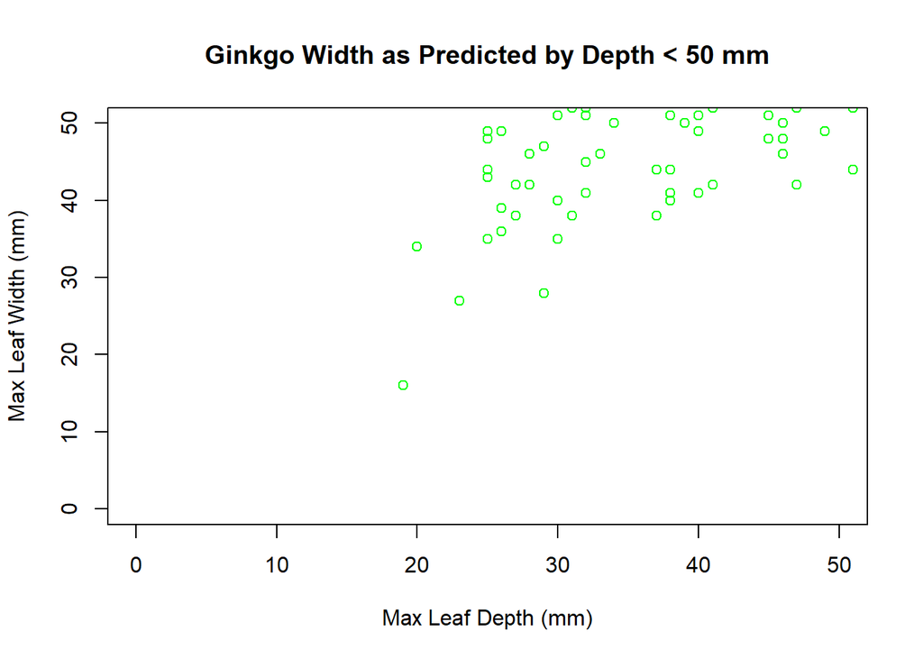

```r
plot(x = ginkgo$max_depth, ginkgo$max_width, xlim = c(0,50), ylim = c(0,50), main = "Ginkgo Width as Predicted by Depth < 50 mm", xlab = "Max Leaf Depth (mm)", ylab = "Max Leaf Width (mm)", col = "green", pch = 1, cex = 1)
```

#### hist()

Create a histogram of penguin flipper lengths. Required arguments: breaks =

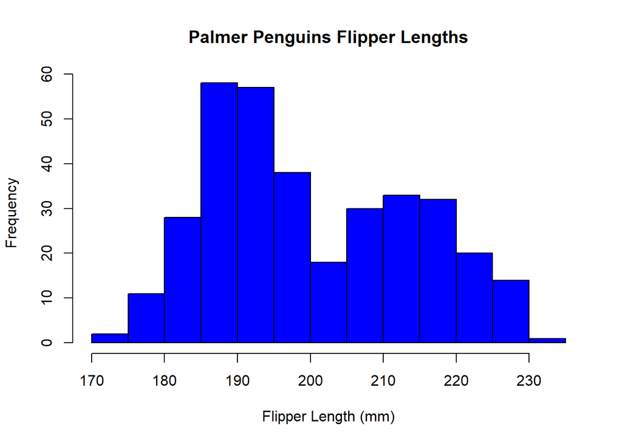

```r
hist(penguins$flipper_length_mm, breaks = 10, main = "Palmer Penguins Flipper Lengths", xlab = "Flipper Length (mm)", col = "blue")
```

### boxplot()

You must include two examples using the ginkgo data:

a simple boxplot of ginkgo petiole lengths

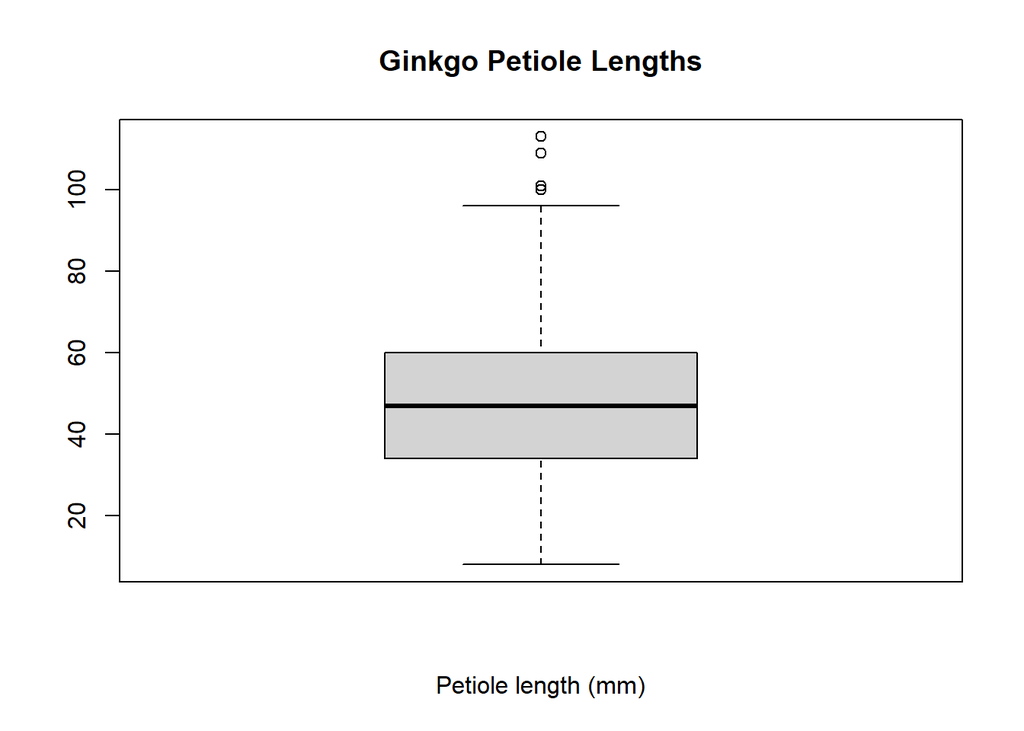

```r
boxplot(ginkgo$petiole_length, main = "Ginkgo Petiole Lengths", xlab = "Petiole length (mm)")
```

conditional boxplot of one of the continuous variables conditioned on the seeds_present column.

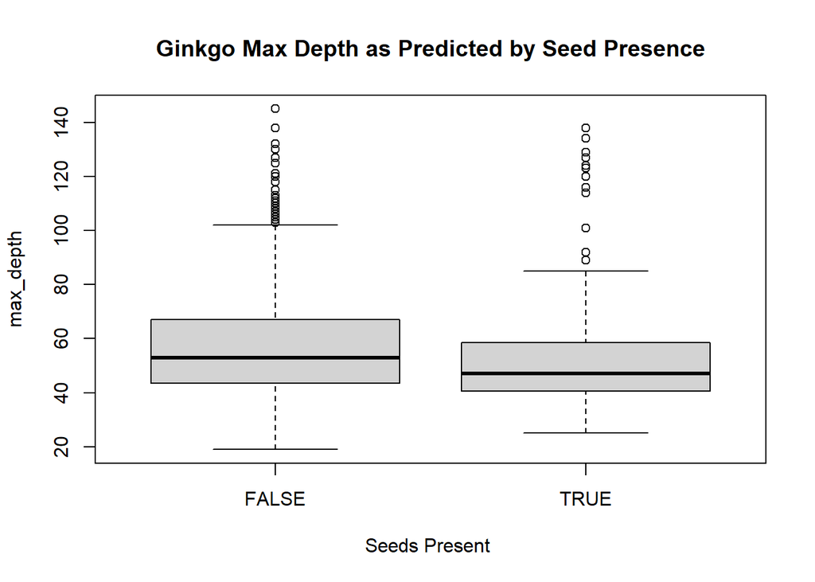

```r
boxplot(formula =  max_depth ~ seeds_present, main = "Ginkgo Max Depth as Predicted by Seed Presence", xlab = "Seeds Present ",
  data = ginkgo)
```

Create a 4-panel figure of histograms, arranged in a 2 by 2 grid. You may use any data you like, but each histogram must be different and have appropriate titles and axes. - par() required arguments: - mrow =

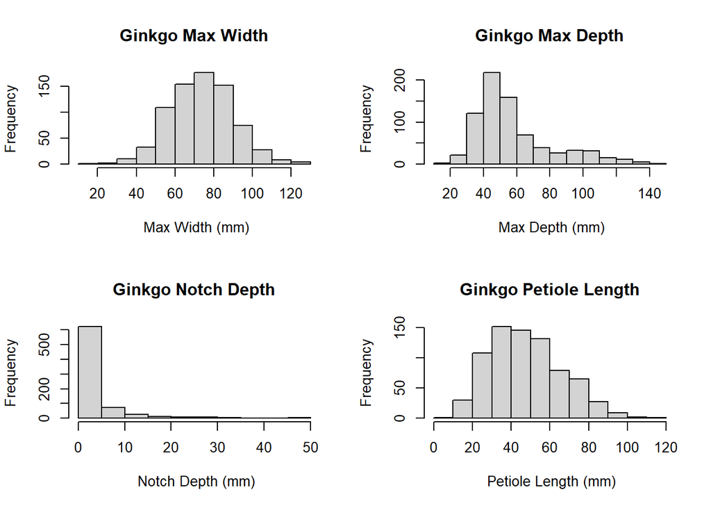

```r
par(mfrow = c(2,2))

hist( ginkgo$max_width, main = "Ginkgo Max Width", xlab = " Max Width (mm)")

hist( ginkgo$max_depth, main = "Ginkgo Max Depth", xlab = " Max Depth (mm)")

hist( ginkgo$notch_depth, main = "Ginkgo Notch Depth", xlab = " Notch Depth (mm)")

hist( ginkgo$petiole_length, main = "Ginkgo Petiole Length", xlab = " Petiole Length (mm)")
```

## Distribution Functions

### dnorm()

**dnorm() is the probability density function for the normal distribution.**

Here is an example that test where 1.2 or 2.4 is more likely:

```r
dnorm(1.2)
```

```
## [1] 0.1941861
```

```r
dnorm(2.4)
```

```
## [1] 0.02239453
```

1.2 is more likely.

### pnorm()

**pnorm() is the cumlative density function for the normal distribution.**

Here is an example to determine the probability of observing a value of less than 1.2 from a normally-distributed population with mean = 2 and standard deviation = 2

```r
pnorm(q = 1.2, mean = 2, sd = 2)
```

```
## [1] 0.3445783
```

### qnorm()

**qnorm() is the Quantile function for the normal distribution that returns the value associated wiith a specific probability (quantile).**

Here is an example to determine the median of the standard normal distribution

```r
qnorm(0.50)
```

```
## [1] 0
```

### dbinom()

**dbinom() is the probability denisty function for the binomial distribution.**

Here is an example that determines the probability of observing a count of exactly 3 successes

```r
dbinom(x = 3, size = 4, p = 0.75)
```

```
## [1] 0.421875
```

### pbinom()

**pbinom() is the cumulative mass function for the binomial distribution.**

Here is an example of observing the probability of observing a count of 3 successes or fewer with 4 trials and probability of success for each trial = 0.75

```r
pbinom(q = 3, size = 4, p = 0.75)
```

```
## [1] 0.6835937
```

### qbinom()

**qbinorm() is the Quantile function for the binomial distribution that returns the value associated with a specific position within data (quantile).**

Here is an example to determine the median (50th quantile) of the binomial distribution with 4 trials and a probability of success for each trial equal to 0.75.

```r
qbinom(p = 0.50, size = 4, prob = 0.75)
```

```
## [1] 3
```